# 利用決策樹模型分析商業中的分類和預測問題

沈辰禧，台灣大學商研碩士

2018年8月

這裡會使用Logistic Regression和Linear Regression所用到的個案內容與資料，建議還沒有上過這兩個個案的同學，先略過這部分的內容，等上完課再回來比較；本個案內容也會直接切入分析的部分，不再重複探索性資料分析的過程。

## **航空業的顧客忠誠度問題- 分類決策樹模型**

## 資料輸入與前處理

首先，我們讀入兩個主要用來分析的資料集合。

```r
library("tidyverse")
library('knitr')

internal.data <- read.csv("internal_data.csv", sep = ',')
survey.data <- read.csv("survey_data.csv", sep = ',')
```

```r
complete.data <- merge(survey.data, internal.data,
                       by = "user_id")
head(complete.data, 5)
```

```
##                            user_id is_loyal depart_on_time arrive_on_time
## 1 00411460f7c92d2124a67ea0f4cb5f85        1              1              1
## 2 006f52e9102a8d3be2fe5614f42ba989        1              0              0
## 3 00ac8ed3b4327bdd4ebbebcb2ba10a00        0              1              1
## 4 00ec53c4682d36f5c4359f4ae7bd7ba1        0              0              0
## 5 01161aaa0b6d1345dd8fe4e481144d84        1              1              1
##   register_method register_rate class seat_rate meal_rate flight_rate
## 1           phone             3     3         3         3           3
## 2      mobile_app             2     2         4         4           2
## 3          others             4     3         1         3           2
## 4          others             3     3         1         2           2
## 5           phone             4     2         4         4           5
##   package_rate tv_ad youtube_ad_1 youtube_ad_2 youtube_ad_3 dm_message
## 1            3     1            0            1            0          0
## 2            4     1            0            0            0          1
## 3            2     0            1            1            1          1
## 4            3     1            1            1            1          1
## 5            3     1            0            0            1          1
##   dm_post dm_email credit_card_vendor credit_card_bonus coupon
## 1       0        0           Vendor A                 2  196.7
## 2       1        0           Vendor A                 3   53.6
## 3       0        1           Vendor C                 1  107.8
## 4       0        1           Vendor B                 2   37.5
## 5       0        0           Vendor B                 1   43.3
```

進行資料格式的轉換

```r
complete.data$user_id <- as.character(complete.data $user_id)
complete.data$credit_card_bonus <- as.factor(complete.data$credit_card_bonus)
complete.data$register_method <- as.factor(complete.data $register_method)
complete.data$class <- as.factor(complete.data$class)


complete.data$is_loyal <- ifelse(complete.data$is_loyal == 1, 'Satisfied', 'Unsatisfied')
```

## 資料建模與分析

### 考量「行銷因素」的分類模型

先用行銷因素建立簡單的決策樹模型，說明模型背後運作的邏輯

我們使用`rpart`套件中的`rpart()`函數進行決策樹分析，其中重要的參數有：

- formula: `Y ~ X1 + X2`
- data: `資料集合名稱`
- split: 選擇使用`gini`(吉尼不純度)或`information`(熵)，預設為`gini`。

```r
library(rpart)

marketing.model <- rpart(is_loyal ~ dm_message + dm_post + dm_email +  credit_card_vendor + credit_card_bonus +
                           tv_ad + youtube_ad_1 + youtube_ad_2 + youtube_ad_3,
                         data = complete.data)
```

接著載入`rpart.plot`套件，呈現決策樹分析的視覺化

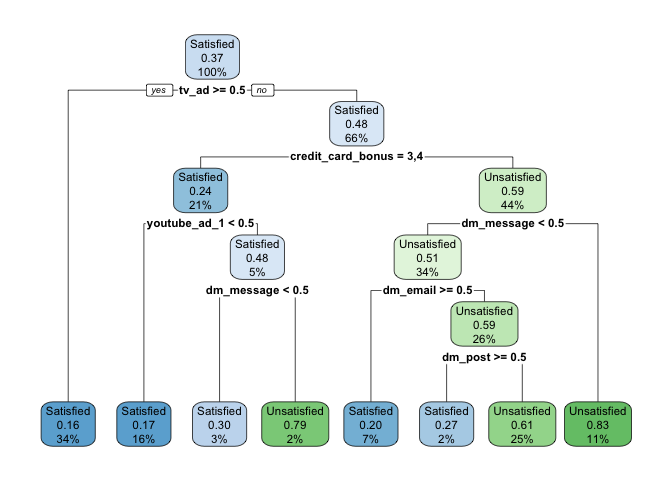

```r
library(rpart.plot)

rpart.plot(marketing.model)
```

### 2. 直接建立包含「行銷活動」與「服務品質」的完整分類模型

將所有變數納入考慮，建立決策樹模型。

```r
full.model <- rpart(is_loyal ~ depart_on_time + arrive_on_time +
                      register_method + register_rate +
                      class + seat_rate + meal_rate +
                      flight_rate + package_rate +
                      dm_message + dm_post + dm_email +
                      credit_card_vendor + credit_card_bonus +
                      tv_ad + youtube_ad_1 + youtube_ad_2 + youtube_ad_3,
                    data = complete.data)
```

同樣將模型視覺化，幫助我們了解模型判斷的邏輯。

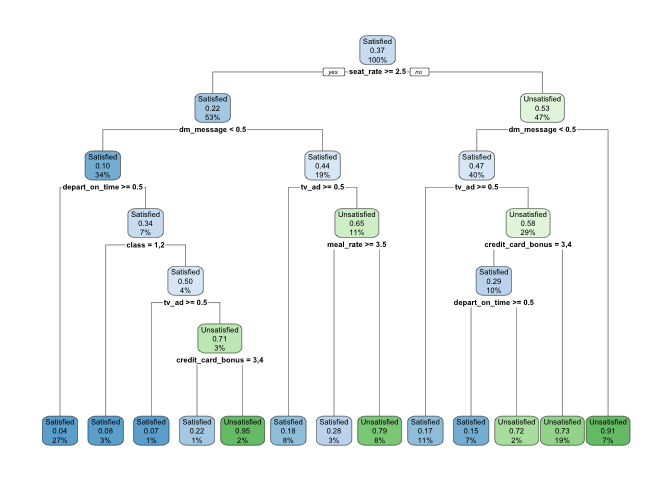

```r
rpart.plot(full.model)
```

接著同樣使用`plotROC`套件，以`AUC`作為指標，衡量模型分類表現

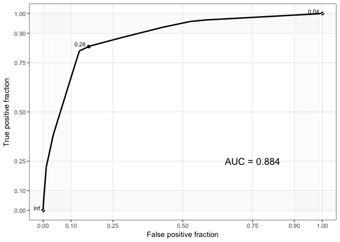

```r
library("plotROC")

predict.prob <- predict(full.model, complete.data)[,2]

predict.table <- data.frame(true_label = complete.data$is_loyal,
                            predict_prob = predict.prob)


basic.plot <- ggplot(predict.table, aes(d = true_label, m = predict.prob)) +
  geom_roc(n.cuts = 3, labelsize = 3, labelround = 2)
basic.plot + style_roc() +
  annotate("text", x = .75, y = .25, size = 5,
           label = paste("AUC =", round(calc_auc(basic.plot)$AUC, 3)))
```

### 決策樹剪枝

決策樹能掌握資料中最枝尾末節的邏輯與關聯，建立完整的分類模型；但這樣的結果是容易遇到過度擬合(over-fitting)的問題，也難以讓決策者理解，因此必須進行剪枝。在`rpart()`中，我們可以透過參數`cp`(complexity parameter)進行剪枝；也可以使用`split`中調整分類的判斷指標。

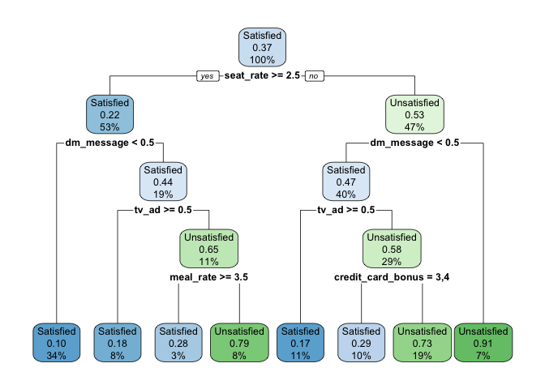

```r
tune.model <- rpart(is_loyal ~ depart_on_time + arrive_on_time +
                      register_method + register_rate +
                      class + seat_rate + meal_rate +
                      flight_rate + package_rate +
                      dm_message + dm_post + dm_email +
                      credit_card_vendor + credit_card_bonus +
                      tv_ad + youtube_ad_1 + youtube_ad_2 + youtube_ad_3,
                    data = complete.data,
                    cp = 0.03,
                    parms = list(split='information'))

rpart.plot(tune.model)
```

接著同樣使用`plotROC`套件，以`AUC`作為指標，衡量模型分類表現

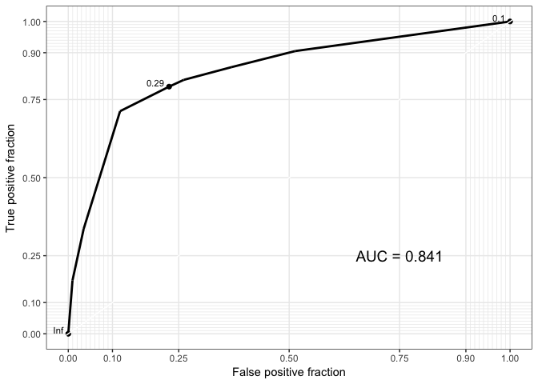

```r
predict.prob <- predict(tune.model, complete.data)[,2]
predict.table <- data.frame(true_label = complete.data$is_loyal,
                            predict_prob = predict.prob)


basic.plot <- ggplot(predict.table, aes(d = true_label, m = predict.prob)) +
  geom_roc(n.cuts = 3, labelsize = 3, labelround = 2)
basic.plot + style_roc() +
  annotate("text", x = .75, y = .25, size = 5,
           label = paste("AUC =", round(calc_auc(basic.plot)$AUC, 3)))
```

## 利用完整的決策樹提出航空業的商業策略建議

從決策樹的源頭到各個分叉的判斷中，我們可以得出以下結論：

- 整體而言，`seat_rate`滿意度是最重要的決定因素
- `dm_message`會造成反感，需要特別注意此狀況
- 有沒有成功接收到電視廣告(`tv_ad`)的資訊，對於滿意度也有較大的影響
- 信用卡紅利(`credit_card_bonus`)和餐點評分(`meal_rate`)也是最終影響滿意度的因素

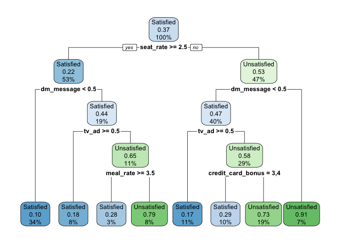

```r
rpart.plot(tune.model)
```

***

## **餐飲業的營收預測和分析- 預測決策樹模型**

## 資料輸入與前處理

```r
SalesData  <- read.csv("Restaurant_Sales_Renew.csv", sep = ',')
```

## 資料建模與分析

### 依照區域分別建立模型

- 區域A的迴歸樹模型

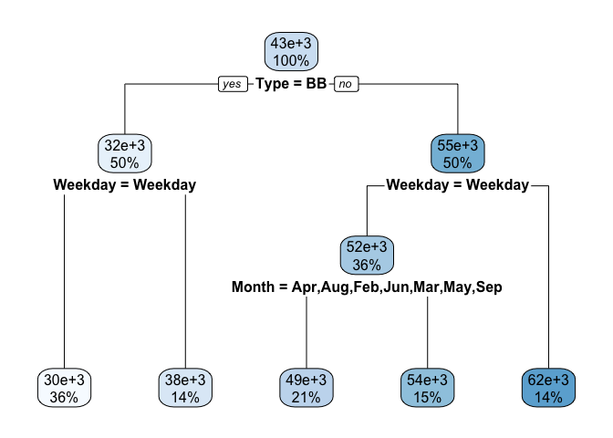

```r
SalesDataA <- SalesData %>% filter( Region %in% 'A')
Model.A.All <- rpart( Sales ~ .,
                      data = SalesDataA[,-c(1,2)])

rpart.plot(Model.A.All)
```

- 區域B的迴歸樹模型

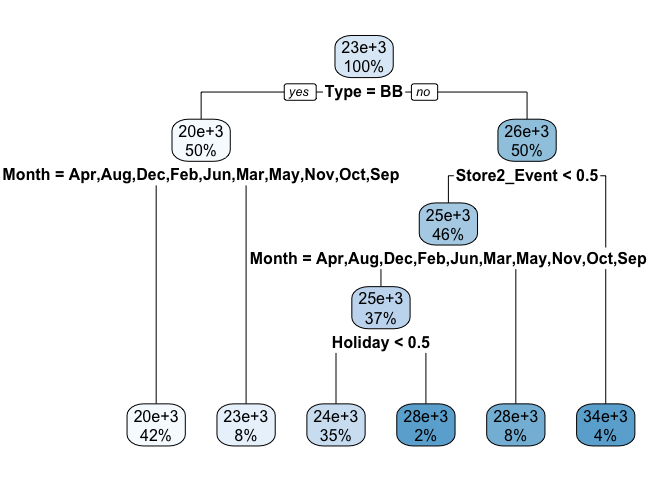

```r
SalesDataB <- SalesData %>% filter( Region %in% 'B')
Model.B.All <- rpart( Sales ~ .,
                      data = SalesDataB[,-c(1,2,4)])

rpart.plot(Model.B.All)
```

### 衡量預測成果

- 誤差：以`RMSE`衡量

```r
RMSE <- function( predict, actual){
  result <- sqrt(mean((predict - actual) ^ 2))
}

cat('RegionA模型的RMSE：\n',RMSE(predict(Model.A.All, SalesDataA), SalesDataA$Sales),'\n',sep = '')
```

```
## RegionA模型的RMSE：
## 5389.392
```

```r
cat('RegionB模型的RMSE：\n',RMSE(predict(Model.B.All, SalesDataB), SalesDataB$Sales),'\n',sep ='')
```

```
## RegionB模型的RMSE：
## 2335.283
```

- 誤差：以`MAPE`衡量

```r
MAPE <- function( predict, actual){
  result <- mean(abs((predict - actual)/actual)) %>% round(3) * 100
}

cat('RegionA模型的MAPE：\n',MAPE(predict(Model.A.All, SalesDataA), SalesDataA$Sales),'%','\n',sep='')
```

```
## RegionA模型的MAPE：
## 9.3%
```

```r
cat('RegionB模型的MAPE：\n',MAPE(predict(Model.B.All, SalesDataB), SalesDataB$Sales),'%','\n',sep='')
```

```
## RegionB模型的MAPE：
## 8.2%
```

### 決策樹剪枝

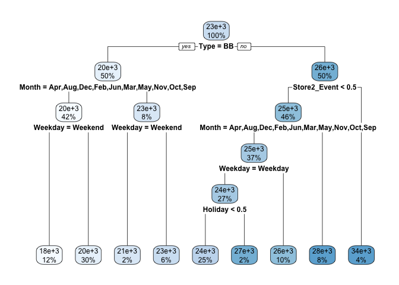

```r
Model.B.Tune <- rpart( Sales ~ .,
                      data = SalesDataB[,-c(1,2)],
                      cp = 0.005)

rpart.plot(Model.B.Tune)
```

衡量模型表現

```r
RMSE <- function( predict, actual){
  result <- sqrt(mean((predict - actual) ^ 2))
}

cat('RegionB模型的RMSE：\n',RMSE(predict(Model.B.Tune, SalesDataB), SalesDataB$Sales),'\n',sep = '')
```

```
## RegionB模型的RMSE：
## 2198.875
```

```r
MAPE <- function( predict, actual){
  result <- mean(abs((predict - actual)/actual)) %>% round(3) * 100
}

cat('RegionB模型的MAPE：\n',MAPE(predict(Model.B.Tune, SalesDataB), SalesDataB$Sales),'%','\n',sep='')
```

```
## RegionB模型的MAPE：
## 7.7%
```

## 利用完整的決策樹提出餐飲業的商業策略建議

對於區域B而言，一個門市的營業額受到以下因素影響：

- 整體而言門市類型是此區域最重要的營收影響因素
- 對於店2來說，百貨公司的特別活動是最重要的影響因素
- 對於區域B的門市而言，月份淡旺季的影響比平假日來得重要，人力和物料等資源的部屬，應優先考慮淡旺季的差別。

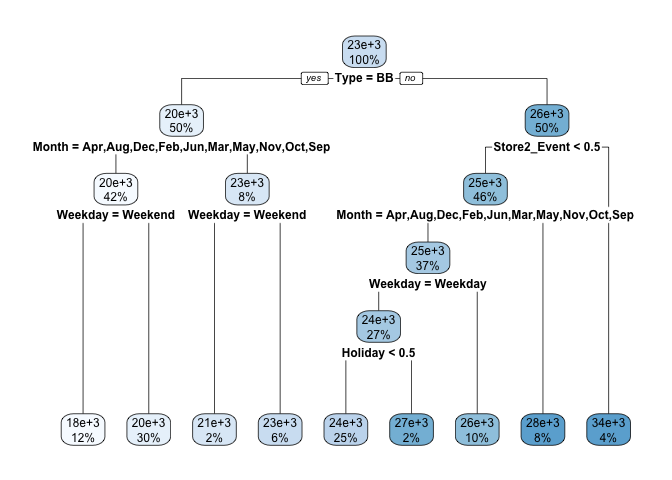

```r
rpart.plot(Model.B.Tune)
```